# QTM 151 - Quiz 2

## Try to submit as an HTML file

Print your name below

```python
# Write your answer here
print ("Daisy Cossio Garcia")
```

```
Daisy Cossio Garcia
```

This quiz is open book

- You can use the lecture notes
- You will get partial credit for attempting the questions
- To get full credit, the code should run as intended
- You should NOT communicate with other students

Print the following message:

"I will abide by Emory's code of conduct"

```python
# Write your answer here:

print ("I will abide by Emory code of conduct ")
```

```
I will abide by Emory code of conduct
```

Import the libraries "numpy", "matplotlib.pyplot", and "pandas"

```python
# Write your answer here

import numpy as np
import matplotlib.pyplot as plt
import pandas as pd
```

Import the dataset "data_quiz/fifa23_players_basic.csv"

- It's a dataset on professional soccer players
- Rows correspond to players (18,539)
- Columns contain attributes of players (32)
- Try to view the dataset before starting

```python
# Write your own code

Soccer = pd.read_csv("data_quiz/fifa23_players_basic.csv")
display(Soccer)
```

|  | Known As | Full Name | Overall | Potential | Value(in Euro) | Positions Played | Best Position | Nationality | Image Link | Age | ... | Preferred Foot | Weak Foot Rating | Skill Moves | International Reputation | National Team Name | National Team Image Link | National Team Position | National Team Jersey Number | Attacking Work Rate | Defensive Work Rate |
| --- | --- | --- | --- | --- | --- | --- | --- | --- | --- | --- | --- | --- | --- | --- | --- | --- | --- | --- | --- | --- | --- |
| 0 | L. Messi | Lionel Messi | 91 | 91 | 54000000 | RW | CAM | Argentina | https://cdn.sofifa.net/players/158/023/23_60.png | 35 | ... | Left | 4 | 4 | 5 | Argentina | https://cdn.sofifa.net/flags/ar.png | RW | 10 | Low | Low |
| 1 | K. Benzema | Karim Benzema | 91 | 91 | 64000000 | CF,ST | CF | France | https://cdn.sofifa.net/players/165/153/23_60.png | 34 | ... | Right | 4 | 4 | 4 | France | https://cdn.sofifa.net/flags/fr.png | ST | 19 | Medium | Medium |
| 2 | R. Lewandowski | Robert Lewandowski | 91 | 91 | 84000000 | ST | ST | Poland | https://cdn.sofifa.net/players/188/545/23_60.png | 33 | ... | Right | 4 | 4 | 5 | Poland | https://cdn.sofifa.net/flags/pl.png | ST | 9 | High | Medium |
| 3 | K. De Bruyne | Kevin De Bruyne | 91 | 91 | 107500000 | CM,CAM | CM | Belgium | https://cdn.sofifa.net/players/192/985/23_60.png | 31 | ... | Right | 5 | 4 | 4 | Belgium | https://cdn.sofifa.net/flags/be.png | RF | 7 | High | High |
| 4 | K. Mbappé | Kylian Mbappé | 91 | 95 | 190500000 | ST,LW | ST | France | https://cdn.sofifa.net/players/231/747/23_60.png | 23 | ... | Right | 4 | 5 | 4 | France | https://cdn.sofifa.net/flags/fr.png | ST | 10 | High | Low |
| ... | ... | ... | ... | ... | ... | ... | ... | ... | ... | ... | ... | ... | ... | ... | ... | ... | ... | ... | ... | ... | ... |
| 18534 | D. Collins | Darren Collins | 47 | 56 | 110000 | ST,RM | CAM | Republic of Ireland | https://cdn.sofifa.net/players/243/725/23_60.png | 21 | ... | Right | 3 | 2 | 1 | - | - | - | - | Medium | Medium |
| 18535 | Yang Dejiang | Dejiang Yang | 47 | 57 | 90000 | CDM | CDM | China PR | https://cdn.sofifa.net/players/261/933/23_60.png | 17 | ... | Right | 3 | 2 | 1 | - | - | - | - | Medium | Medium |
| 18536 | L. Mullan | Liam Mullan | 47 | 67 | 130000 | CM | RM | Northern Ireland | https://cdn.sofifa.net/players/267/823/23_60.png | 18 | ... | Right | 3 | 2 | 1 | - | - | - | - | High | Medium |
| 18537 | D. McCallion | Daithí McCallion | 47 | 61 | 100000 | CB | CB | Republic of Ireland | https://cdn.sofifa.net/players/267/824/23_60.png | 17 | ... | Right | 3 | 2 | 1 | - | - | - | - | Medium | Medium |
| 18538 | N. Rabha | Nabin Rabha | 47 | 50 | 60000 | LB | LB | India | https://cdn.sofifa.net/players/261/424/23_60.png | 25 | ... | Left | 3 | 2 | 1 | - | - | - | - | Medium | Medium |

18539 rows × 32 columns

(a) Create a function and apply it to a column

Step 1:

- Define a function with a parameter "age_player"
- If "age_player < 20", status = "Less than 20"
- If "age_player >= 20", status = "20 or older"
- The function returns "status"

Step 2:

- Extract the column "Age" in the dataset

(be carefeful to write the "A" capitalized)

- Create a new variable called "age_bracket"

to assign each player to the correct age bracket

HINT: Use the ".apply()" function

```python
# Write your own code

def fn_age (age_player):
    if (age_player < 20 ):
        status = "Less than 20"
    else:
        status = "20 or older"
    return(status)

Soccer ["age_player"] = Soccer ["Age"].apply(fn_age)
```

(b) Use queries + global variables

- Compute the mean of the column "Value(in Euro)"

and store it as a variable

- Subset the players whose value is above the mean value  
  using ".query()"

HINT: Remember that there is a special syntax for  
when the column names have spaces (see Lecture 10)  
Reference the column as `` `Value(in Euro)` `` inside .query()

```python
# Write your own code

subset = Soccer ["Value(in Euro)"]. mean()
subset
subset_Soccer = Soccer.query ("`Value(in Euro)` > 2875461.40")
display(subset_Soccer)
```

|  | Known As | Full Name | Overall | Potential | Value(in Euro) | Positions Played | Best Position | Nationality | Image Link | Age | ... | Weak Foot Rating | Skill Moves | International Reputation | National Team Name | National Team Image Link | National Team Position | National Team Jersey Number | Attacking Work Rate | Defensive Work Rate | age_player |
| --- | --- | --- | --- | --- | --- | --- | --- | --- | --- | --- | --- | --- | --- | --- | --- | --- | --- | --- | --- | --- | --- |
| 0 | L. Messi | Lionel Messi | 91 | 91 | 54000000 | RW | CAM | Argentina | https://cdn.sofifa.net/players/158/023/23_60.png | 35 | ... | 4 | 4 | 5 | Argentina | https://cdn.sofifa.net/flags/ar.png | RW | 10 | Low | Low | 20 or older |
| 1 | K. Benzema | Karim Benzema | 91 | 91 | 64000000 | CF,ST | CF | France | https://cdn.sofifa.net/players/165/153/23_60.png | 34 | ... | 4 | 4 | 4 | France | https://cdn.sofifa.net/flags/fr.png | ST | 19 | Medium | Medium | 20 or older |
| 2 | R. Lewandowski | Robert Lewandowski | 91 | 91 | 84000000 | ST | ST | Poland | https://cdn.sofifa.net/players/188/545/23_60.png | 33 | ... | 4 | 4 | 5 | Poland | https://cdn.sofifa.net/flags/pl.png | ST | 9 | High | Medium | 20 or older |
| 3 | K. De Bruyne | Kevin De Bruyne | 91 | 91 | 107500000 | CM,CAM | CM | Belgium | https://cdn.sofifa.net/players/192/985/23_60.png | 31 | ... | 5 | 4 | 4 | Belgium | https://cdn.sofifa.net/flags/be.png | RF | 7 | High | High | 20 or older |
| 4 | K. Mbappé | Kylian Mbappé | 91 | 95 | 190500000 | ST,LW | ST | France | https://cdn.sofifa.net/players/231/747/23_60.png | 23 | ... | 4 | 5 | 4 | France | https://cdn.sofifa.net/flags/fr.png | ST | 10 | High | Low | 20 or older |
| ... | ... | ... | ... | ... | ... | ... | ... | ... | ... | ... | ... | ... | ... | ... | ... | ... | ... | ... | ... | ... | ... |
| 7066 | F. Rieder | Fabian Rieder | 68 | 83 | 2900000 | CAM,CM | CAM | Switzerland | https://cdn.sofifa.net/players/259/306/23_60.png | 20 | ... | 3 | 2 | 1 | - | https://cdn.sofifa.net/flags/ch.png | - | - | High | Medium | 20 or older |
| 7071 | J. Bakayoko | Johan Bakayoko | 68 | 85 | 3100000 | RW | LM | Belgium | https://cdn.sofifa.net/players/265/450/23_60.png | 19 | ... | 3 | 3 | 1 | - | https://cdn.sofifa.net/flags/be.png | - | - | High | Medium | Less than 20 |
| 7090 | M. Arezo | Matías Arezo | 68 | 81 | 2900000 | ST,CAM | ST | Uruguay | https://cdn.sofifa.net/players/254/653/23_60.png | 19 | ... | 3 | 4 | 1 | - | https://cdn.sofifa.net/flags/uy.png | - | - | High | Medium | Less than 20 |
| 7096 | Y. Kallon | Yayah Kallon | 68 | 82 | 3000000 | RM,RW,CF | ST | Sierra Leone | https://cdn.sofifa.net/players/262/333/23_60.png | 21 | ... | 2 | 3 | 1 | - | - | - | - | High | Low | 20 or older |
| 7168 | M. Soulé | Matías Soulé | 68 | 85 | 3100000 | RW | LM | Argentina | https://cdn.sofifa.net/players/265/695/23_60.png | 19 | ... | 4 | 4 | 1 | - | https://cdn.sofifa.net/flags/ar.png | - | - | High | Medium | Less than 20 |

3216 rows × 33 columns

(c) Use sorting + ".iloc[]"

- Use ".sort_values()" to order the "Age" column

from youngest to oldest

- Get a subset with the 5 youngest players

```python
# Write your own code

Soccersorted = Soccer.sort_values(by = "Age", ascending=True )
display(Soccersorted)

Five_Youngest_Players = display (Soccersorted.iloc[[0,1,2,3,4],:])
display(Five_Youngest_Players)
```

|  | Known As | Full Name | Overall | Potential | Value(in Euro) | Positions Played | Best Position | Nationality | Image Link | Age | ... | Weak Foot Rating | Skill Moves | International Reputation | National Team Name | National Team Image Link | National Team Position | National Team Jersey Number | Attacking Work Rate | Defensive Work Rate | age_player |
| --- | --- | --- | --- | --- | --- | --- | --- | --- | --- | --- | --- | --- | --- | --- | --- | --- | --- | --- | --- | --- | --- |
| 17956 | A. Dithmer | Andreas Dithmer | 53 | 76 | 275000 | GK | GK | Denmark | https://cdn.sofifa.net/players/269/573/23_60.png | 16 | ... | 2 | 1 | 1 | - | https://cdn.sofifa.net/flags/dk.png | - | - | Medium | Medium | Less than 20 |
| 18014 | J. Ardila | José Ardila | 53 | 73 | 250000 | CM | CAM | Venezuela | https://cdn.sofifa.net/players/268/892/23_60.png | 16 | ... | 3 | 2 | 1 | - | https://cdn.sofifa.net/flags/ve.png | - | - | Medium | Medium | Less than 20 |
| 16084 | S. Ngoma | Serge Ngoma | 58 | 82 | 650000 | RW | RM | United States | https://cdn.sofifa.net/players/267/796/23_60.png | 16 | ... | 3 | 2 | 1 | - | https://cdn.sofifa.net/flags/us.png | - | - | High | Medium | Less than 20 |
| 11481 | O. Vargas | Obed Vargas | 64 | 81 | 1500000 | CM,CDM,RM | CAM | United States | https://cdn.sofifa.net/players/263/701/23_60.png | 16 | ... | 3 | 3 | 1 | - | https://cdn.sofifa.net/flags/us.png | - | - | High | Medium | Less than 20 |
| 17591 | A. Madaliński | Alan Madaliński | 54 | 68 | 210000 | GK | GK | Poland | https://cdn.sofifa.net/players/270/590/23_60.png | 16 | ... | 3 | 1 | 1 | - | https://cdn.sofifa.net/flags/pl.png | - | - | Medium | Medium | Less than 20 |
| ... | ... | ... | ... | ... | ... | ... | ... | ... | ... | ... | ... | ... | ... | ... | ... | ... | ... | ... | ... | ... | ... |
| 2423 | Rubén Castro | Rubén Castro Martín | 73 | 73 | 0 | ST | ST | Spain | https://cdn.sofifa.net/players/115/909/23_60.png | 41 | ... | 3 | 3 | 2 | - | https://cdn.sofifa.net/flags/es.png | - | - | Medium | Low | 20 or older |
| 4499 | G. Pegolo | Gianluca Pegolo | 70 | 70 | 180000 | GK | GK | Italy | https://cdn.sofifa.net/players/106/795/23_60.png | 41 | ... | 2 | 1 | 1 | - | https://cdn.sofifa.net/flags/it.png | - | - | Medium | Medium | 20 or older |
| 3276 | S. Torrico | Sebastián Torrico | 72 | 72 | 250000 | GK | GK | Argentina | https://cdn.sofifa.net/players/216/692/23_60.png | 42 | ... | 2 | 1 | 1 | - | https://cdn.sofifa.net/flags/ar.png | - | - | Medium | Medium | 20 or older |
| 13548 | S. Lukić | Stojan Lukić | 62 | 62 | 45000 | GK | GK | Bosnia and Herzegovina | https://cdn.sofifa.net/players/213/483/23_60.png | 42 | ... | 2 | 1 | 1 | - | - | - | - | Medium | Medium | 20 or older |
| 592 | G. Buffon | Gianluigi Buffon | 79 | 79 | 1900000 | GK | GK | Italy | https://cdn.sofifa.net/players/001/179/23_60.png | 44 | ... | 2 | 1 | 4 | - | https://cdn.sofifa.net/flags/it.png | - | - | Medium | Medium | 20 or older |

18539 rows × 33 columns

|  | Known As | Full Name | Overall | Potential | Value(in Euro) | Positions Played | Best Position | Nationality | Image Link | Age | ... | Weak Foot Rating | Skill Moves | International Reputation | National Team Name | National Team Image Link | National Team Position | National Team Jersey Number | Attacking Work Rate | Defensive Work Rate | age_player |
| --- | --- | --- | --- | --- | --- | --- | --- | --- | --- | --- | --- | --- | --- | --- | --- | --- | --- | --- | --- | --- | --- |
| 17956 | A. Dithmer | Andreas Dithmer | 53 | 76 | 275000 | GK | GK | Denmark | https://cdn.sofifa.net/players/269/573/23_60.png | 16 | ... | 2 | 1 | 1 | - | https://cdn.sofifa.net/flags/dk.png | - | - | Medium | Medium | Less than 20 |
| 18014 | J. Ardila | José Ardila | 53 | 73 | 250000 | CM | CAM | Venezuela | https://cdn.sofifa.net/players/268/892/23_60.png | 16 | ... | 3 | 2 | 1 | - | https://cdn.sofifa.net/flags/ve.png | - | - | Medium | Medium | Less than 20 |
| 16084 | S. Ngoma | Serge Ngoma | 58 | 82 | 650000 | RW | RM | United States | https://cdn.sofifa.net/players/267/796/23_60.png | 16 | ... | 3 | 2 | 1 | - | https://cdn.sofifa.net/flags/us.png | - | - | High | Medium | Less than 20 |
| 11481 | O. Vargas | Obed Vargas | 64 | 81 | 1500000 | CM,CDM,RM | CAM | United States | https://cdn.sofifa.net/players/263/701/23_60.png | 16 | ... | 3 | 3 | 1 | - | https://cdn.sofifa.net/flags/us.png | - | - | High | Medium | Less than 20 |
| 17591 | A. Madaliński | Alan Madaliński | 54 | 68 | 210000 | GK | GK | Poland | https://cdn.sofifa.net/players/270/590/23_60.png | 16 | ... | 3 | 1 | 1 | - | https://cdn.sofifa.net/flags/pl.png | - | - | Medium | Medium | Less than 20 |

5 rows × 33 columns

```
None
```

(d) Create a function with four inputs $f(y,x,b0,b1)$

$\qquad e2 = (y - b_0 - b_1 * x)^2$

- The function should return the mean of e2
- This is the mean-square error (mse)
- Call the function "fn_mse"
- Let $y$ be the column "Potential"
- Let $x$ be the column "Age"
- Does

$\qquad (b_0 = 80, b_1 = -1)$ or  
$\qquad (b_0 = 80, b_1 =-0.4)$ or  
$\qquad (b_0 = 80, b_1 = 1)$  
produce the lowest value of mse?

```python
# Write your own code
e2 =np.e**2
def fn_mse(b0,b1):
    e2 = (y - b0 - b1 * x)**2
    return (e2)

y = Soccer["Potential"]
x = Soccer["Age"]

f1 = fn_mse(b0= 80, b1= -1 )
f2 = fn_mse(b0= 80, b1= -0.4)
f3 = fn_mse(b0= 80, b1= 1)

print(f1)
print(f2)
print(f3)
```

```
0        2116
1        2025
2        1936
3        1764
4        1444
         ...
18534       9
18535      36
18536      25
18537       4
18538      25
Length: 18539, dtype: int64
0        625.00
1        605.16
2        585.64
```

[output cut: 21 more lines]

(e) Split a dataset into subsets

- Create `list_status = [0,1]`
- Create `list_prob = [0.5, 0.5]`
- Create a new variable $n$ with the number of rows of the dataset
- Use

```
np.random.choice(list_status,
                     size = n,
                     p = list_prob)
```

$\qquad$ to create a new column called "status"  
$\qquad$ which randomly assigns each row to "0" or "1"  
$\qquad$ with equal probability

- Use .query() to subset all observations with status == 0.

store it in a new dataset called "data0"

- Use .query() to subset all observations with status == 1.

store it in a new dataset called "data1"

```python
# Write your own code

list_status = [0,1]
list_prob = [0.5, 0.5 ]
n = 18539
Soccer ["status"] = np.random.choice(list_status,
                                         size = n,
                                         p = list_prob)

display(Soccer)

data0 = Soccer.query('status == 0')
data1 = Soccer.query('status == 1')

display(data0.describe())
display(data1.describe())
```

|  | Known As | Full Name | Overall | Potential | Value(in Euro) | Positions Played | Best Position | Nationality | Image Link | Age | ... | Skill Moves | International Reputation | National Team Name | National Team Image Link | National Team Position | National Team Jersey Number | Attacking Work Rate | Defensive Work Rate | age_player | status |
| --- | --- | --- | --- | --- | --- | --- | --- | --- | --- | --- | --- | --- | --- | --- | --- | --- | --- | --- | --- | --- | --- |
| 0 | L. Messi | Lionel Messi | 91 | 91 | 54000000 | RW | CAM | Argentina | https://cdn.sofifa.net/players/158/023/23_60.png | 35 | ... | 4 | 5 | Argentina | https://cdn.sofifa.net/flags/ar.png | RW | 10 | Low | Low | 20 or older | 0 |
| 1 | K. Benzema | Karim Benzema | 91 | 91 | 64000000 | CF,ST | CF | France | https://cdn.sofifa.net/players/165/153/23_60.png | 34 | ... | 4 | 4 | France | https://cdn.sofifa.net/flags/fr.png | ST | 19 | Medium | Medium | 20 or older | 1 |
| 2 | R. Lewandowski | Robert Lewandowski | 91 | 91 | 84000000 | ST | ST | Poland | https://cdn.sofifa.net/players/188/545/23_60.png | 33 | ... | 4 | 5 | Poland | https://cdn.sofifa.net/flags/pl.png | ST | 9 | High | Medium | 20 or older | 0 |
| 3 | K. De Bruyne | Kevin De Bruyne | 91 | 91 | 107500000 | CM,CAM | CM | Belgium | https://cdn.sofifa.net/players/192/985/23_60.png | 31 | ... | 4 | 4 | Belgium | https://cdn.sofifa.net/flags/be.png | RF | 7 | High | High | 20 or older | 1 |
| 4 | K. Mbappé | Kylian Mbappé | 91 | 95 | 190500000 | ST,LW | ST | France | https://cdn.sofifa.net/players/231/747/23_60.png | 23 | ... | 5 | 4 | France | https://cdn.sofifa.net/flags/fr.png | ST | 10 | High | Low | 20 or older | 1 |
| ... | ... | ... | ... | ... | ... | ... | ... | ... | ... | ... | ... | ... | ... | ... | ... | ... | ... | ... | ... | ... | ... |
| 18534 | D. Collins | Darren Collins | 47 | 56 | 110000 | ST,RM | CAM | Republic of Ireland | https://cdn.sofifa.net/players/243/725/23_60.png | 21 | ... | 2 | 1 | - | - | - | - | Medium | Medium | 20 or older | 1 |
| 18535 | Yang Dejiang | Dejiang Yang | 47 | 57 | 90000 | CDM | CDM | China PR | https://cdn.sofifa.net/players/261/933/23_60.png | 17 | ... | 2 | 1 | - | - | - | - | Medium | Medium | Less than 20 | 0 |
| 18536 | L. Mullan | Liam Mullan | 47 | 67 | 130000 | CM | RM | Northern Ireland | https://cdn.sofifa.net/players/267/823/23_60.png | 18 | ... | 2 | 1 | - | - | - | - | High | Medium | Less than 20 | 1 |
| 18537 | D. McCallion | Daithí McCallion | 47 | 61 | 100000 | CB | CB | Republic of Ireland | https://cdn.sofifa.net/players/267/824/23_60.png | 17 | ... | 2 | 1 | - | - | - | - | Medium | Medium | Less than 20 | 1 |
| 18538 | N. Rabha | Nabin Rabha | 47 | 50 | 60000 | LB | LB | India | https://cdn.sofifa.net/players/261/424/23_60.png | 25 | ... | 2 | 1 | - | - | - | - | Medium | Medium | 20 or older | 0 |

18539 rows × 34 columns

|  | Overall | Potential | Value(in Euro) | Age | Height(in cm) | Weight(in kg) | TotalStats | BaseStats | Wage(in Euro) | Release Clause | Joined On | Weak Foot Rating | Skill Moves | International Reputation | status |
| --- | --- | --- | --- | --- | --- | --- | --- | --- | --- | --- | --- | --- | --- | --- | --- |
| count | 9296.000000 | 9296.000000 | 9.296000e+03 | 9296.000000 | 9296.000000 | 9296.000000 | 9296.000000 | 9296.000000 | 9296.000000 | 9.296000e+03 | 9296.000000 | 9296.000000 | 9296.000000 | 9296.000000 | 9296.0 |
| mean | 65.836274 | 71.006454 | 2.807022e+06 | 25.216760 | 181.497526 | 75.194277 | 1603.815297 | 357.805077 | 8650.968158 | 4.935257e+06 | 2020.352087 | 2.942233 | 2.374247 | 1.083907 | 0.0 |
| std | 6.748544 | 6.164620 | 7.295914e+06 | 4.713049 | 6.841115 | 6.960823 | 270.768892 | 39.413458 | 18725.343426 | 1.391621e+07 | 2.079191 | 0.670438 | 0.769021 | 0.352743 | 0.0 |
| min | 47.000000 | 48.000000 | 0.000000e+00 | 16.000000 | 155.000000 | 53.000000 | 777.000000 | 224.000000 | 0.000000 | 0.000000e+00 | 2005.000000 | 1.000000 | 1.000000 | 1.000000 | 0.0 |
| 25% | 62.000000 | 67.000000 | 5.000000e+05 | 21.000000 | 177.000000 | 70.000000 | 1472.750000 | 331.000000 | 1000.000000 | 6.740000e+05 | 2020.000000 | 3.000000 | 2.000000 | 1.000000 | 0.0 |
| 50% | 66.000000 | 71.000000 | 1.000000e+06 | 25.000000 | 182.000000 | 75.000000 | 1640.000000 | 358.000000 | 3000.000000 | 1.500000e+06 | 2021.000000 | 3.000000 | 2.000000 | 1.000000 | 0.0 |
| 75% | 70.000000 | 75.000000 | 2.000000e+06 | 29.000000 | 186.000000 | 80.000000 | 1787.000000 | 385.000000 | 8000.000000 | 3.300000e+06 | 2022.000000 | 3.000000 | 3.000000 | 1.000000 | 0.0 |
| max | 91.000000 | 92.000000 | 1.090000e+08 | 42.000000 | 206.000000 | 105.000000 | 2305.000000 | 502.000000 | 420000.000000 | 2.453000e+08 | 2022.000000 | 5.000000 | 5.000000 | 5.000000 | 0.0 |

|  | Overall | Potential | Value(in Euro) | Age | Height(in cm) | Weight(in kg) | TotalStats | BaseStats | Wage(in Euro) | Release Clause | Joined On | Weak Foot Rating | Skill Moves | International Reputation | status |
| --- | --- | --- | --- | --- | --- | --- | --- | --- | --- | --- | --- | --- | --- | --- | --- |
| count | 9243.000000 | 9243.000000 | 9.243000e+03 | 9243.000000 | 9243.000000 | 9243.000000 | 9243.000000 | 9243.000000 | 9243.000000 | 9.243000e+03 | 9243.000000 | 9243.000000 | 9243.000000 | 9243.000000 | 9243.0 |
| mean | 65.867900 | 71.026939 | 2.944293e+06 | 25.264200 | 181.604457 | 75.153413 | 1600.404090 | 358.088175 | 8999.102023 | 5.228958e+06 | 2020.382884 | 2.950665 | 2.358001 | 1.088716 | 1.0 |
| std | 6.828484 | 6.221462 | 7.961528e+06 | 4.723436 | 6.875086 | 7.066586 | 275.548426 | 39.844753 | 20172.437941 | 1.539416e+07 | 2.033159 | 0.677130 | 0.775795 | 0.364702 | 0.0 |
| min | 47.000000 | 49.000000 | 0.000000e+00 | 16.000000 | 158.000000 | 49.000000 | 759.000000 | 226.000000 | 0.000000 | 0.000000e+00 | 2002.000000 | 1.000000 | 1.000000 | 1.000000 | 1.0 |
| 25% | 62.000000 | 67.000000 | 4.750000e+05 | 22.000000 | 177.000000 | 70.000000 | 1468.000000 | 331.000000 | 1000.000000 | 6.600000e+05 | 2020.000000 | 3.000000 | 2.000000 | 1.000000 | 1.0 |
| 50% | 66.000000 | 71.000000 | 9.750000e+05 | 25.000000 | 182.000000 | 75.000000 | 1641.000000 | 359.000000 | 3000.000000 | 1.500000e+06 | 2021.000000 | 3.000000 | 2.000000 | 1.000000 | 1.0 |
| 75% | 70.000000 | 75.000000 | 2.000000e+06 | 29.000000 | 186.000000 | 80.000000 | 1784.500000 | 385.000000 | 8000.000000 | 3.400000e+06 | 2022.000000 | 3.000000 | 3.000000 | 1.000000 | 1.0 |
| max | 91.000000 | 95.000000 | 1.905000e+08 | 44.000000 | 203.000000 | 104.000000 | 2312.000000 | 501.000000 | 450000.000000 | 3.667000e+08 | 2022.000000 | 5.000000 | 5.000000 | 5.000000 | 1.0 |

(f) Create two overlapping histogram plots

- This function requires the two datasets you created in (e)
- Display the distribution of "Age" for "data0" and "data1"
- Use the "alpha" option to make the graphs semitransparent
- You will need to add a legend, label the axes, and the title

Note: The goal of this question is to illustrate that random  
assignment produces very similar distributions between two groups

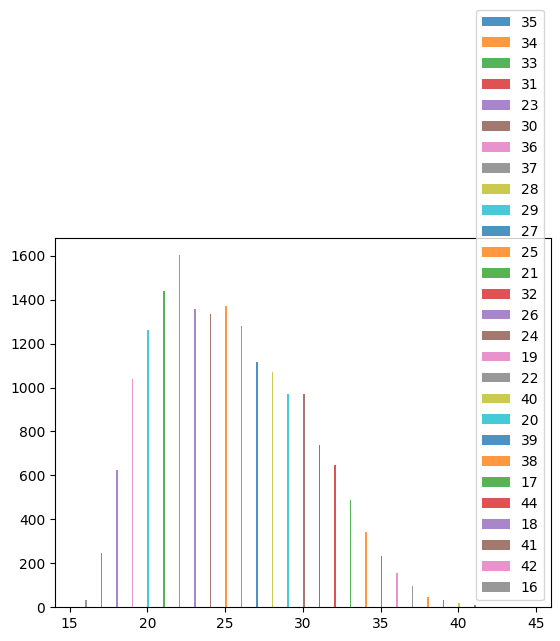

```python
# Write your own code
list_unique_Ages = pd.unique(Soccer["Age"])

for category_value in list_unique_Ages:
    temporarydataframe = Soccer.query("Age == @category_value")
    plt.hist(temporarydataframe["Age"],alpha = 0.8)

plt.legend(labels = list_unique_Ages)
plt.show()
```